# Assignment 3 - Diagnosing Schizophrenia from Voice

## 3.2 Second phase: Forest Engineering

In this section, you will try to optimize the performance of the model developed in the previous phase by adding a new random forest model, upgraded with feature engineering and parameter tuning procedures of your own choosing.

```r
#curious about the correlation of the numeric variables; many are derived from the same thing, so might be bad to have? though could also help the algorithm; helpful redundancy?
numeric_df <- df[sapply(df, is.numeric) & !sapply(df, is.factor)]
correlation_matrix <- cor(numeric_df)

hc <- findCorrelation(correlation_matrix, cutoff=0.5) #setting the cut off fairly high
not_cor_variables <- df[c(hc)]
not_cor_variables <-  not_cor_variables[, c("ID", "Diagnosis", setdiff(names(not_cor_variables), c("ID", "Diagnosis")))] #reordering

#these could be good ones to keep? though i dont know fully if having correlated variables is bad? also doesnt the ML automatically figure this out, or?

print(paste0(paste(names(df)[-hc], collapse = ", "), " - These should be omitted due to high correlation? Is this even remotely correct?"))
```

```
## [1] "total_pause_duration, n_pauses, syllable_duration, average_syllable_duration, p_mean, p_max, p_median - These should be omitted due to high correlation? Is this even remotely correct?"
```

```r
#formula <- Diagnosis ~ ID + phonation_duration + p_sd + p_min + p_mad + articulation_rate + p_coefvar + n_syllables + duration + average_pause_duration + p_iqr + speech_rate + syllables_phonation_duration?
#would it even make a difference? have I done this correctly?

to_remove <- names(df[-hc])
```

```r
#trying to omit the correlated predictors from earlier, wound up creating a new recipe since step_rm was finnicky
predictors <- this_recipe$var_info$variable
new_predictors <- setdiff(predictors, c(to_remove, "Diagnosis"))


cor_removed_recipe <-
  recipe(
    Diagnosis ~ ID + duration + phonation_duration + n_syllables + speech_rate + articulation_rate + syllables_phonation_duration + average_pause_duration + p_iqr + p_mad + p_coefvar + p_sd + p_min,
    data = training(split_df)
  ) %>% #had to do by hand unfortunately, couldnt figure it out otherwise
  step_normalize(all_numeric_predictors(),-all_outcomes()) %>%
  step_YeoJohnson(all_numeric_predictors(),-all_outcomes()) %>%
  update_role(ID, new_role = "ID")

summary(cor_removed_recipe)
```

```
## # A tibble: 14 × 4
##    variable                     type      role      source
##    <chr>                        <list>    <chr>     <chr>
##  1 ID                           <chr [3]> ID        original
##  2 duration                     <chr [2]> predictor original
##  3 phonation_duration           <chr [2]> predictor original
##  4 n_syllables                  <chr [2]> predictor original
##  5 speech_rate                  <chr [2]> predictor original
##  6 articulation_rate            <chr [2]> predictor original
##  7 syllables_phonation_duration <chr [2]> predictor original
##  8 average_pause_duration       <chr [2]> predictor original
##  9 p_iqr                        <chr [2]> predictor original
## 10 p_mad                        <chr [2]> predictor original
## 11 p_coefvar                    <chr [2]> predictor original
## 12 p_sd                         <chr [2]> predictor original
## 13 p_min                        <chr [2]> predictor original
## 14 Diagnosis                    <chr [3]> outcome   original
```

```r
#this seems to make no difference, really
```

```r
#new rf model to be upgraded with feature engineering, tripartite best
#also normalization

valid_split <- initial_validation_split(
   df,
  prop = c(0.7, 0.15),
  strata = Diagnosis
)
#splits into test, training AND validation

cor_removed_recipe <-
  recipe(
    Diagnosis ~ ID + duration + phonation_duration + n_syllables + speech_rate + articulation_rate + syllables_phonation_duration + average_pause_duration + p_iqr + p_mad + p_coefvar + p_sd + p_min,
    data = training(valid_split) #using validation here
  ) %>%
  step_normalize(all_numeric_predictors(),-all_outcomes()) %>%
  update_role(ID, new_role = "ID")
#normalizing the variables, center and scale them, since good for unsupervised learning? but might need to be better justified
#In general you should be careful about using -all_outcomes() if a *_predictors() selector would do what you want.


rf_flow <- workflow() %>%
  add_model(rand_forest(
    mode = "classification",
    engine = "randomForest",
    trees = tune(), #tune these
    min_n = tune()
  )) %>%
  add_recipe(cor_removed_recipe)

tripartite <- tune_grid(
  rf_flow,
  vfold_cv(validation(valid_split)),
  grid = grid_max_entropy(extract_parameter_set_dials(rf_flow), size = 10)
)
tripartite %>% collect_metrics()
```

```
## # A tibble: 20 × 8
##    trees min_n .metric  .estimator  mean     n std_err .config
##    <int> <int> <chr>    <chr>      <dbl> <int>   <dbl> <chr>
##  1   310     2 accuracy binary     0.582    10  0.0201 Preprocessor1_Model01
##  2   310     2 roc_auc  binary     0.592    10  0.0433 Preprocessor1_Model01
##  3  1351    19 accuracy binary     0.547    10  0.0262 Preprocessor1_Model02
##  4  1351    19 roc_auc  binary     0.594    10  0.0405 Preprocessor1_Model02
##  5   655    26 accuracy binary     0.565    10  0.0347 Preprocessor1_Model03
##  6   655    26 roc_auc  binary     0.599    10  0.0418 Preprocessor1_Model03
##  7   907    40 accuracy binary     0.582    10  0.0428 Preprocessor1_Model04
##  8   907    40 roc_auc  binary     0.610    10  0.0435 Preprocessor1_Model04
##  9   310    13 accuracy binary     0.548    10  0.0361 Preprocessor1_Model05
## 10   310    13 roc_auc  binary     0.585    10  0.0395 Preprocessor1_Model05
## 11  1998    25 accuracy binary     0.564    10  0.0306 Preprocessor1_Model06
## 12  1998    25 roc_auc  binary     0.603    10  0.0431 Preprocessor1_Model06
## 13   958     3 accuracy binary     0.556    10  0.0283 Preprocessor1_Model07
## 14   958     3 roc_auc  binary     0.582    10  0.0410 Preprocessor1_Model07
## 15    75    38 accuracy binary     0.574    10  0.0432 Preprocessor1_Model08
## 16    75    38 roc_auc  binary     0.609    10  0.0410 Preprocessor1_Model08
## 17  1990    40 accuracy binary     0.590    10  0.0370 Preprocessor1_Model09
## 18  1990    40 roc_auc  binary     0.616    10  0.0418 Preprocessor1_Model09
## 19  1813     3 accuracy binary     0.573    10  0.0361 Preprocessor1_Model10
## 20  1813     3 roc_auc  binary     0.585    10  0.0423 Preprocessor1_Model10
```

```r
#doing tripartite now
```

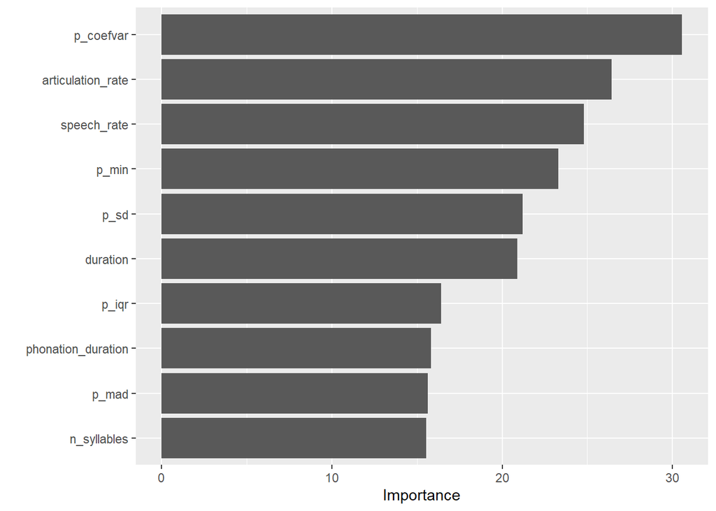

```r
final_fit <- last_fit(
  finalize_workflow(rf_flow, select_best(tripartite, "roc_auc")),
  valid_split,
  add_validation_set = TRUE
)
#using the best tripartite and finalizing workplace, using validation set

#Plotting Variable Importance with vip
vip_plot <-
final_fit %>%
extract_fit_parsnip() %>%
vip::vip()
vip_plot
```

```r
predicted <- final_fit %>%
  pull(.predictions) %>%
  bind_cols() %>%
  mutate(
    Predicted = .pred_class,
    Prob_SCZ = .pred_SCZ,
    type = "prob"
  )

conf_matrix <- confusionMatrix(predicted$Predicted, testing(valid_split)$Diagnosis)
conf_matrix
```

```
## Confusion Matrix and Statistics
##
##           Reference
## Prediction CTRL SCZ
##       CTRL   85  54
##       SCZ    43  54
##
##                Accuracy : 0.589
##                  95% CI : (0.5233, 0.6524)
##     No Information Rate : 0.5424
##     P-Value [Acc > NIR] : 0.08472
##
##                   Kappa : 0.1654
##
##  Mcnemar's Test P-Value : 0.30994
##
##             Sensitivity : 0.6641
##             Specificity : 0.5000
##          Pos Pred Value : 0.6115
##          Neg Pred Value : 0.5567
##              Prevalence : 0.5424
##          Detection Rate : 0.3602
##    Detection Prevalence : 0.5890
##       Balanced Accuracy : 0.5820
##
##        'Positive' Class : CTRL
##
```

```r
predicted
```

```
## # A tibble: 236 × 9
##    .pred_CTRL .pred_SCZ  .row .pred_class Diagnosis .config   Predicted Prob_SCZ
##         <dbl>     <dbl> <int> <fct>       <fct>     <chr>     <fct>        <dbl>
##  1      0.407     0.593    18 SCZ         CTRL      Preproce… SCZ          0.593
##  2      0.426     0.574    22 SCZ         CTRL      Preproce… SCZ          0.574
##  3      0.348     0.652    28 SCZ         CTRL      Preproce… SCZ          0.652
##  4      0.554     0.446    33 CTRL        CTRL      Preproce… CTRL         0.446
##  5      0.298     0.702    35 SCZ         CTRL      Preproce… SCZ          0.702
##  6      0.268     0.732    37 SCZ         CTRL      Preproce… SCZ          0.732
##  7      0.720     0.280    44 CTRL        CTRL      Preproce… CTRL         0.280
##  8      0.508     0.492    62 CTRL        CTRL      Preproce… CTRL         0.492
##  9      0.711     0.289    73 CTRL        CTRL      Preproce… CTRL         0.289
## 10      0.843     0.157    74 CTRL        CTRL      Preproce… CTRL         0.157
## # ℹ 226 more rows
## # ℹ 1 more variable: type <chr>
```

```r
#accuracy not much better?
```

## 3.3 Third phase: Another Algorithm

For this final part, add a supervised algorithm to the workflow set and compare its performance to the previous ones. Here again, you are free to choose any algorithm, but it its important that we know what you’re doing and why you are doing it. In other words, tell us a bit about the algorithm you’re using and why you chose it.

For a detailed list of the model types, engines, and arguments that can be used with the tidymodels framework, have a look here https://www.tidymodels.org/find/parsnip/#models

```r
#racing method with anova, not tuning the recipe though?

training_folds <- vfold_cv(df, v = 10) #splitting into folds for training

m1 <-
  svm_rbf(cost = tune(), rbf_sigma = tune()) %>%
  set_engine("kernlab") %>%
  set_mode("classification")

m1_grid <-
  m1 %>%
  hardhat::extract_parameter_set_dials() %>%
  grid_latin_hypercube(size = 25)

wflow <-
  workflow() %>%
  add_model(m1) %>%
  add_recipe(cor_removed_recipe)

anova_race <- wflow %>% tune_race_anova(resamples = training_folds, grid = m1_grid)
```

```r
show_best(anova_race, metric = "roc_auc", n = 2)
```

```
## # A tibble: 1 × 8
##    cost rbf_sigma .metric .estimator  mean     n std_err .config
##   <dbl>     <dbl> <chr>   <chr>      <dbl> <int>   <dbl> <chr>
## 1  1.38    0.0160 roc_auc binary     0.661    10  0.0102 Preprocessor1_Model05
```

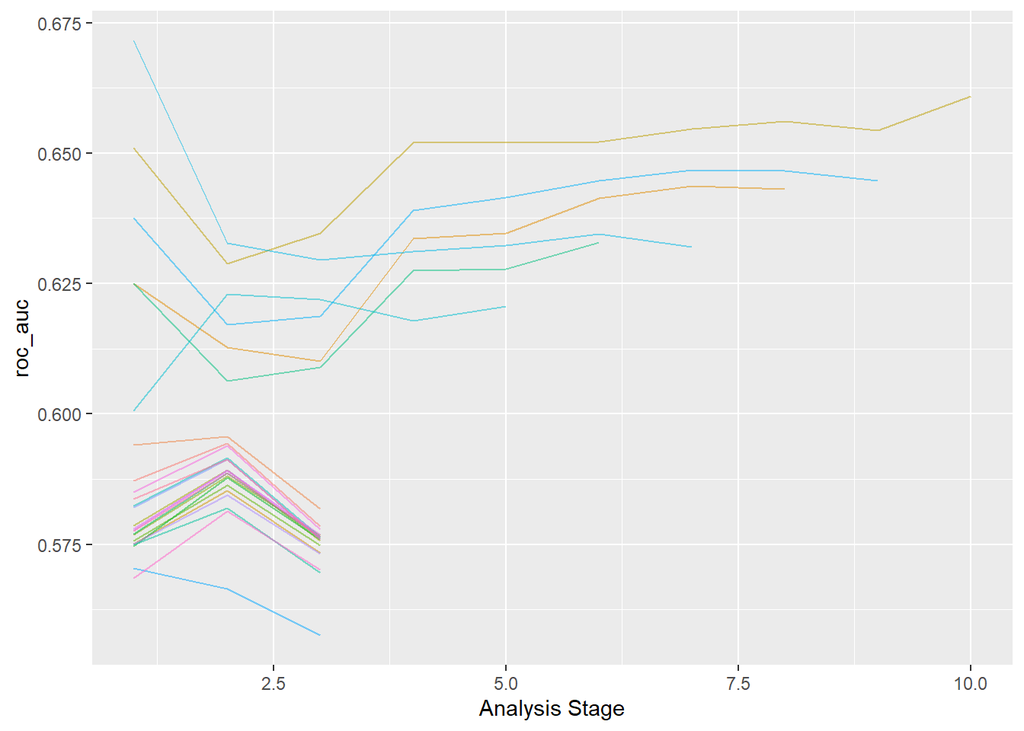

```r
plot_race(anova_race)
```

```r
best_model <- select_best(anova_race, metric = "roc_auc")

final_rf <- finalize_model(
  m1,
  best_model
) #am i using this bit correctly?

final_res <- cor_removed_recipe %>%
  workflow() %>%
  add_model(final_rf)

final_fit  <- final_res %>%
last_fit(split_df)

final_metrics <- final_fit %>%
  collect_metrics()

final_metrics
```

```
## # A tibble: 2 × 4
##   .metric  .estimator .estimate .config
##   <chr>    <chr>          <dbl> <chr>
## 1 accuracy binary         0.636 Preprocessor1_Model1
## 2 roc_auc  binary         0.684 Preprocessor1_Model1
```

```r
#better performance than the later model? or more or less the same?

predicted <- data.frame(final_fit$.predictions)

conf_matrix <-
  confusionMatrix(
    data = predicted$.pred_class,  # Accessing the predictions column
    reference = predicted$Diagnosis,
    positive = "SCZ"
  )
print(conf_matrix)
```

```
## Confusion Matrix and Statistics
##
##           Reference
## Prediction CTRL SCZ
##       CTRL  202 118
##       SCZ    53  97
##
##                Accuracy : 0.6362
##                  95% CI : (0.5909, 0.6798)
##     No Information Rate : 0.5426
##     P-Value [Acc > NIR] : 2.461e-05
##
##                   Kappa : 0.2492
##
##  Mcnemar's Test P-Value : 9.871e-07
##
##             Sensitivity : 0.4512
##             Specificity : 0.7922
##          Pos Pred Value : 0.6467
##          Neg Pred Value : 0.6312
##              Prevalence : 0.4574
##          Detection Rate : 0.2064
##    Detection Prevalence : 0.3191
##       Balanced Accuracy : 0.6217
##
##        'Positive' Class : SCZ
##
```

```r
rda_spec <- discrim_regularized(frac_common_cov = tune(), frac_identity = tune()) %>%
    set_engine("klaR")%>%
  set_mode("classification")

ctrl <- control_race(verbose_elim = TRUE)

grid_anova <- rda_spec %>%
    tune_race_anova(cor_removed_recipe, resamples = training_folds, grid = 10, control = ctrl)
```

```
## ℹ Racing will maximize the roc_auc metric.
## ℹ Resamples are analyzed in a random order.
## ℹ Fold08: 1 eliminated; 9 candidates remain.
##
## ℹ Fold07: 2 eliminated; 7 candidates remain.
##
## ℹ Fold06: 0 eliminated; 7 candidates remain.
##
## ℹ Fold10: 1 eliminated; 6 candidates remain.
##
## ℹ Fold09: 3 eliminated; 3 candidates remain.
##
## ℹ Fold05: 0 eliminated; 3 candidates remain.
##
## ℹ Fold02: 0 eliminated; 3 candidates remain.
```

```r
show_best(grid_anova, metric = "roc_auc", n = 2)
```

```
## # A tibble: 2 × 8
##   frac_common_cov frac_identity .metric .estimator  mean     n std_err .config
##             <dbl>         <dbl> <chr>   <chr>      <dbl> <int>   <dbl> <chr>
## 1           0.665        0.0808 roc_auc binary     0.638    10  0.0141 Preproce…
## 2           0.103        0.292  roc_auc binary     0.638    10  0.0132 Preproce…
```

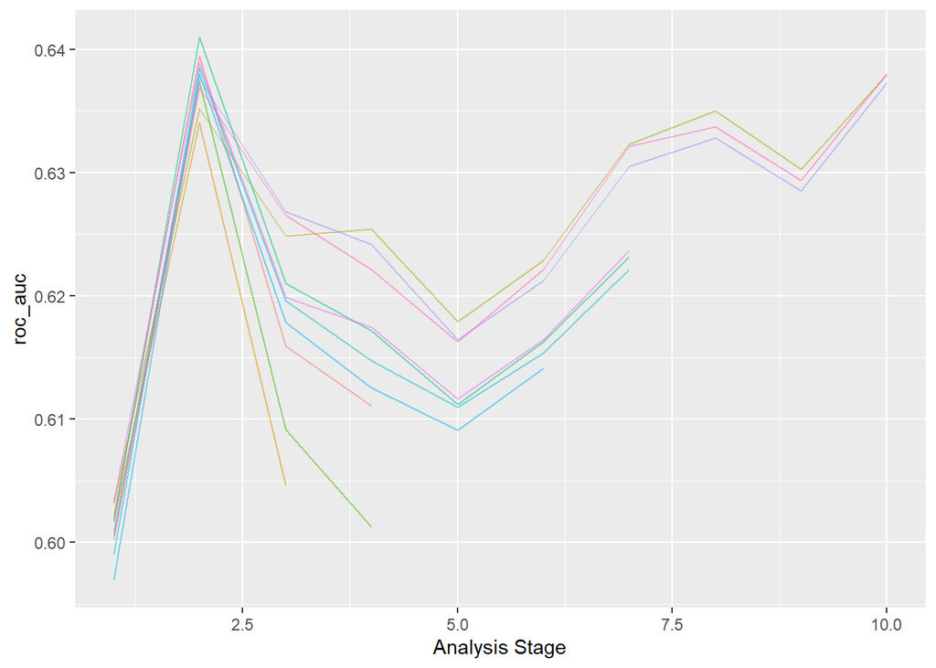

```r
plot_race(grid_anova)
```

```r
best_model <- select_best(grid_anova, metric = "roc_auc")

final_model <- finalize_model(
  rda_spec,
  best_model
) #is this a correct way to finalize?

final_res <- cor_removed_recipe %>%
  workflow() %>%
  add_model(final_model)

final_fit  <- final_res %>%
last_fit(split_df)

predicted <- data.frame(final_fit$.predictions)

conf_matrix <-
  confusionMatrix(
    data = predicted$.pred_class,  # Accessing the predictions column
    reference = predicted$Diagnosis,
    positive = "SCZ"
  )
print(conf_matrix)
```

```
## Confusion Matrix and Statistics
##
##           Reference
## Prediction CTRL SCZ
##       CTRL  198 110
##       SCZ    57 105
##
##                Accuracy : 0.6447
##                  95% CI : (0.5995, 0.688)
##     No Information Rate : 0.5426
##     P-Value [Acc > NIR] : 4.550e-06
##
##                   Kappa : 0.2701
##
##  Mcnemar's Test P-Value : 5.725e-05
##
##             Sensitivity : 0.4884
##             Specificity : 0.7765
##          Pos Pred Value : 0.6481
##          Neg Pred Value : 0.6429
##              Prevalence : 0.4574
##          Detection Rate : 0.2234
##    Detection Prevalence : 0.3447
##       Balanced Accuracy : 0.6324
##
##        'Positive' Class : SCZ
##
```

```r
pacman::p_load("gbm") #trying out gbm

ctrl <- trainControl(method = "cv",
                     summaryFunction = twoClassSummary,
                     classProbs = TRUE,
                     savePredictions = TRUE)


model <- train(
  cor_removed_recipe,
  data = training(split_df),
  method = "gbm",
  trControl = ctrl,
  tuneLength = 5,
  metric = "ROC",
  verbose = FALSE
)
predictions <- predict(model, newdata = testing(split_df))

predicted_labels <- factor(predictions, levels = c("SCZ", "CTRL"))
actual_labels <- factor(testing(split_df)$Diagnosis, levels = c("SCZ", "CTRL"))

conf_matrix <- confusionMatrix(data = predicted_labels, reference = actual_labels)
conf_matrix
```

```
## Confusion Matrix and Statistics
##
##           Reference
## Prediction SCZ CTRL
##       SCZ  104   78
##       CTRL 111  177
##
##                Accuracy : 0.5979
##                  95% CI : (0.552, 0.6425)
##     No Information Rate : 0.5426
##     P-Value [Acc > NIR] : 0.008917
##
##                   Kappa : 0.18
##
##  Mcnemar's Test P-Value : 0.019930
##
##             Sensitivity : 0.4837
##             Specificity : 0.6941
##          Pos Pred Value : 0.5714
##          Neg Pred Value : 0.6146
##              Prevalence : 0.4574
##          Detection Rate : 0.2213
##    Detection Prevalence : 0.3872
##       Balanced Accuracy : 0.5889
##
##        'Positive' Class : SCZ
##
```

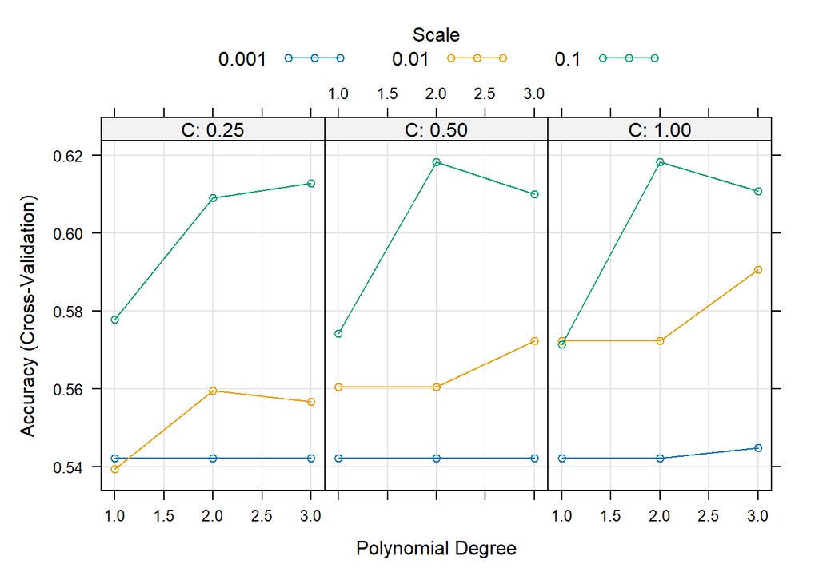

```r
svmPoly_model <- train(
  cor_removed_recipe, #normalization; is that a smart choice? was removing correlates ok? did it make a difference
  data = training(split_df),
  method = "svmPoly",
  trControl = trainControl(method = "cv"), #since cv, couldnt i use the whole data?
  tuneLength = 3, #lowered it
  verbose = F
)
plot(svmPoly_model)
```

```r
max(svmPoly_model$results$Accuracy)
```

```
## [1] 0.6182152
```

```r
svmPoly_predict <- predict(svmPoly_model, newdata = testing(split_df))
conf_matrix <- confusionMatrix(data = svmPoly_predict, reference = testing(split_df)$Diagnosis, positive = "SCZ")
print(conf_matrix)
```

```
## Confusion Matrix and Statistics
##
##           Reference
## Prediction CTRL SCZ
##       CTRL  191 115
##       SCZ    64 100
##
##                Accuracy : 0.6191
##                  95% CI : (0.5735, 0.6632)
##     No Information Rate : 0.5426
##     P-Value [Acc > NIR] : 0.0004734
##
##                   Kappa : 0.2182
##
##  Mcnemar's Test P-Value : 0.0001861
##
##             Sensitivity : 0.4651
##             Specificity : 0.7490
##          Pos Pred Value : 0.6098
##          Neg Pred Value : 0.6242
##              Prevalence : 0.4574
##          Detection Rate : 0.2128
##    Detection Prevalence : 0.3489
##       Balanced Accuracy : 0.6071
##
##        'Positive' Class : SCZ
##
```

```r
final_model_svm <-
  svm_rbf() %>% #using svm
  set_engine("kernlab") %>%
parsnip::set_mode("classification")

final_wf <- workflow() %>%
  add_model(final_model_svm)%>%
  add_recipe(cor_removed_recipe)

rf_fit <- final_wf %>% fit(training(split_df))

max(model$results$ROC)
```

```
## [1] 0.6472831
```

```r
#names(getModelInfo())

predict <- predict(model, newdata = testing(split_df))
conf_matrix <- confusionMatrix(data = predict, reference = testing(split_df)$Diagnosis, positive = "SCZ")
print(conf_matrix)
```

```
## Confusion Matrix and Statistics
##
##           Reference
## Prediction CTRL SCZ
##       CTRL  177 111
##       SCZ    78 104
##
##                Accuracy : 0.5979
##                  95% CI : (0.552, 0.6425)
##     No Information Rate : 0.5426
##     P-Value [Acc > NIR] : 0.008917
##
##                   Kappa : 0.18
##
##  Mcnemar's Test P-Value : 0.019930
##
##             Sensitivity : 0.4837
##             Specificity : 0.6941
##          Pos Pred Value : 0.5714
##          Neg Pred Value : 0.6146
##              Prevalence : 0.4574
##          Detection Rate : 0.2213
##    Detection Prevalence : 0.3872
##       Balanced Accuracy : 0.5889
##
##        'Positive' Class : SCZ
##
```

```r
predict <- predict(rf_fit, new_data = testing(split_df))
conf_matrix <- confusionMatrix(data = predict$.pred_class, reference = testing(split_df)$Diagnosis, positive = "SCZ")
print(conf_matrix)
```

```
## Confusion Matrix and Statistics
##
##           Reference
## Prediction CTRL SCZ
##       CTRL  174 101
##       SCZ    81 114
##
##                Accuracy : 0.6128
##                  95% CI : (0.5671, 0.657)
##     No Information Rate : 0.5426
##     P-Value [Acc > NIR] : 0.001246
##
##                   Kappa : 0.2141
##
##  Mcnemar's Test P-Value : 0.159020
##
##             Sensitivity : 0.5302
##             Specificity : 0.6824
##          Pos Pred Value : 0.5846
##          Neg Pred Value : 0.6327
##              Prevalence : 0.4574
##          Detection Rate : 0.2426
##    Detection Prevalence : 0.4149
##       Balanced Accuracy : 0.6063
##
##        'Positive' Class : SCZ
##
```

# 4 Discussion: Methodology and Results

## 4.1 Finally, briefly summarize and discuss the methodological choices you’ve made throughout as well as the results obtained at the different modeling stages. In particular, I would like to get your input as regards to the following questions:

I messed around a lot with my models and as a result I have a lot of filler and some of it may be messy and even incorrectly done.

Anyway, I attempted the following:

I figured the parameters available to us likely have high correlation and that this might be a problem, as the model would simply overfit on the training data parameters in such a way where it does not have a clear understanding of how the variables appear in nature; i.e. it cannot distinguish the real influence/importance of each parameter. As such, I tried to cull them by calculating the correlations and omitting any over 0.5, and making these the predictors. I did this in a way that might not be entirely optimal; I assume a ML solution with tuning the recipe would’ve sufficed better.

Afterwards, I messed about with various ML methods, such as tuning a tripartite and picking the best model, anova racing using kernlab and klaR engines, gbm (gradient boosting machine), svmPoly (support vector machine model). They gave mostly the same results of 60-65% accuracy and similar ROC. It’s possible that I was doing them incorrectly, or that one of my pre-processing steps, such as the recipe I chose, may have lessened the data/training quality.

## 4.2 Based on the performance evaluation of your models, do you think the second and third phase of the third section were worth the extra effort? Was any model successful in diagnosing schizophrenia from voice?

It appears that I am not yet capable of actually creating or tuning a model to be better than the default; i.e. I was stuck at around 64% throughout my attempts, which was not better than what I had in the 2nd part. I assume there’s something I’m still missing or that the act of tuning and training a model takes extensive trial and error alongside statistical knowledge–that is, choices that are justified with more than idle curiosity and have some sort of knowledge of the data distribution or statistical methods behind them (the latter two I am still lacking in).

That said, it could be not worth the effort for this task–I’m not sure, though I do suspect it isn’t.

## 4.3 How do the predictive models you built relate to the descriptive analysis conducted in the second section?

I struggled with tying the predictive models to the descriptive analysis, but I did attempt to remove the features that I imagined to be less useful for prediction; that is, the features that correlated heavily with each other. Many of these were “not statistically significant” when I did a quick Wilcox on them earlier on. I’m not sure whether a quick statistical significance test is warranted, especially considering that I did not check assumptions; I just figured the “statistically likely” values were the ones likely to differentiate the groups from each other, and therefore be useful for a classification task.

It does appear that I may have been correct about the SCZ and CTRL speech and pitch parameters overlapping too much on the density plot for it to be a slam dunk classification task.

## 4.4 What is the explanatory scope of the analyses and procedures you conducted here, if any?

From the visual analyses alone, it is rather apparent that schizophrenic and non-schizophrenic individuals have more or less the same “distribution” of vocal characteristics outside of schizophrenics “trending towards the bottom” on variables such as pitch and number of syllables spoken. It is very likely that, as a result, it is rather difficult to distinguish one from the other unless you happen to have a schizophrenic with a very “stereotypically extreme” distribution of pitch and speech characteristics. As such, I’m not sure whether speech characteristics are enough alone for the sake of distinguishing the two from each other (reliably anyway).

While it’s possible my models were all just poorly optimized and handled, it seems to me that a percentage of much over 70% would be overfitting on the training data/data available to the study. I suppose it could still be used as one of many markers of schizophrenia though, just not as a standalone one.